# COMPSCI 527 Homework 2

## Homework Submission Workflow

When you submit your work, follow the instructions on the [submission workflow page](https://www.cs.duke.edu/courses/spring24/compsci527/homework/workflow.html) **scrupulously** for full credit.

## Part 1: Linear Regression

Linear regression fits an affine model $\mathbb{R}^d \rightarrow \mathbb{R}$ of the form

$$ \hat{y} = b + \mathbf{w}^T \mathbf{x} $$

to a set of $n$ pairs

$$ T = \{(\mathbf{x}_1, y_1), \ldots (\mathbf{x}_n, y_n)\} $$

where $\mathbf{x}_i\in\mathbb{R}^d$ and $y_i\in\mathbb{R}$.

More specifically, it finds a real number $\hat{b}$ and a real vector $\hat{\mathbf{w}}\in\mathbb{R}^d$ that minimizes the average over all pairs in $T$ of some measure of discrepancy between the values $\hat{y}_i = \hat{b} + \hat{\mathbf{w}}^T \mathbf{x}_i$ predicted by the model and the actual values $y_i$:

$$ \hat{b}, \hat{\mathbf{w}} = \arg\min_{b, \mathbf{w}} \frac{1}{n} \sum_{i=1}^n \rho(\phi_i) \;\;\;\mbox{where}\;\;\; \phi_i = b + \mathbf{w}^T \mathbf{x}_i - y_i\;. $$

The quantity $\phi_i$ is called the $i$-th *residual* and $\rho(\phi_i)$ is the $i$-th *loss.* **Please pay attention to this distinction.**

The average discrepancy is a function of both the parameters $b, \mathbf{w}$ of the model and the data points in $T$. To make this dependency explicit we first bundle the model parameters into a single vector $\mathbf{z} = (b, w_1, \ldots, w_d)^T$ and then call the average discrepancy defined above the *empirical risk* $L_T$:

$$ L_T(\mathbf{z}) = \frac{1}{n} \sum_{i=1}^n \rho(\phi_i(\mathbf{z})) \;. $$

With this notation, we can rewrite the linear regression problem more simply as follows:

$$ \hat{\mathbf{z}} = \arg\min_{\mathbf{z}} L_T(\mathbf{z}) \;. $$

You have studied in previous courses how to solve this minimization problem when

$$ \rho(\phi) = \phi^2 \;. $$

In this case, the regression problem is called *Ordinary Least Squares* (OLS). The empirical risk is a quadratic function of $\mathbf{z}$ in this case, and the OLS problem can be solved by finding the minimum-norm solution to the linear system

$$ X\mathbf{z} = \mathbf{y} \;. $$

Here, $X$ is an $n$ by $d+1$ matrix and $\mathbf{y}$ is an $n$-dimensional vector:

$$ X = \left[\begin{array}{cc} 1 & \mathbf{x}_1^T \\ \vdots & \vdots \\ 1 & \mathbf{x}_n^T \end{array}\right] \;\;\;\mbox{and}\;\;\; \mathbf{y} = \left[\begin{array}{c} y_1 \\ \vdots \\ y_n \end{array}\right] \;. $$

#### Data

Problems in this part use the data retrieved below. The variable `noisy_line` will contain a dictionary with the following keys and values:

- `noisy_line['x']` is a `numpy` array of shape `(30, 1)` containing the abscissas of 30 points on the plane. This array does *not* include the vector of ones in the definition of $X$ above.
- `noisy_line['y']` is a `numpy` array of shape `(30,)` containing the ordinates of those points.

```python
import urllib.request
import ssl
from os import path as osp
import shutil


def retrieve(file_name, semester='spring24', homework=2):
    if osp.exists(file_name):
        print('Using previously downloaded file {}'.format(file_name))
    else:
        context = ssl._create_unverified_context()
        fmt = 'https://www2.cs.duke.edu/courses/{}/compsci527/homework/{}/{}'
        url = fmt.format(semester, homework, file_name)
        with urllib.request.urlopen(url, context=context) as response:
            with open(file_name, 'wb') as file:
                shutil.copyfileobj(response, file)
        print('Downloaded file {}'.format(file_name))
```

```python
import pickle


file_name = 'noisy_line.pkl'
retrieve(file_name)
with open(file_name, 'rb') as file:
    noisy_line = pickle.load(file)
```

```
Using previously downloaded file noisy_line.pkl
```

### Problem 1.1

Use the function `numpy.linalg.lstsq` to write a function with header

```
def ols(t):
```

that returns a single `numpy` vector with the solution $\hat{\mathbf{z}}$ to the OLS problem. The argument `t` to `ols` is a dictionary with the following keys and values:

- `t['x']` is a $n\times d$ `numpy` array whose rows are equal to the vectors $\mathbf{x}_1, \ldots, \mathbf{x}_n$ in $T$.
- `t['y']` is a `numpy` vector whose $n$ entries are the values $y_1,\ldots, y_n$ in $T$.

After showing your code, plot the points $(x_i, y_i)$ in `noisy_line`, retrieved above, and the line whose parameters $\hat{\mathbf{z}}$ are estimated by `ols` from those points. Your plot should have the following:

- Two thin lines for the coordinate axes.
- An understandable title that gives the estimated parameters with three decimal digits after the period.

#### Programming Notes

- Your function needs to add a column of ones in the beginning of `t['x']` to form $X$. You will need to do that later as well, so it's best to write a helper function for this operation, even if it is very simple (use `numpy.column_stack`).
- While you test your function with $d=1$ here, make sure it works for any positive integer dimension $d$.
- You will make similar plots later on, so it is best to write a helper function to make the plot. Start simple with this function. If later problems call for more features for the plot function, you can just go back and extend its definition to fit the additional requirements.
- No axis labels are needed for this plot.
- Use `matplotlib.pyplot.axis('equal')` for a correct aspect ratio.

### Problem 1.2 (Exam Style Except for the Code)

For later reference, we rewrite the quadratic risk $$ L_T(\mathbf{z}) = \frac{1}{n} \sum_{i=1}^n \rho(\phi_i(\mathbf{z})) $$ as follows: $$ L_T(\mathbf{z}) = \text{mean}(\rho(\boldsymbol{\varphi}_T(\mathbf{z}))) $$ where $\boldsymbol{\varphi}_T(\mathbf{z})$ is a vector containing the $n$ residuals $ \phi_i(\mathbf{z}) \;. $

Applying the function $\rho$ to a vector means to apply it to each of the vector's entries, and therefore the quantity $\rho(\boldsymbol{\varphi}_T(\mathbf{z}))$ is itself a vector with $n$ entries.

In this way, the gradient $\nabla L_T(\mathbf{z})$ of $L_T(\mathbf{z})$ can be written in two steps:

First compute the Jacobian of $\boldsymbol{\varphi}_T(\mathbf{z})$ with respect to $\mathbf{z}$, defined as the following $n\times (d+1)$ matrix: $$ J_T(\mathbf{z}) = \left[\begin{array}{cc} \frac{\partial \phi_1}{\partial z_0} & \ldots & \frac{\partial \phi_1}{\partial z_d} \\ \vdots & & \vdots \\ \frac{\partial \phi_n}{\partial z_0} & \ldots & \frac{\partial \phi_n}{\partial z_d} \end{array}\right] $$ where $\boldsymbol{\varphi}_T(\mathbf{z}) = (\phi_1,\ldots, \phi_n)^T$.

Then, the gradient $\nabla L_T(\mathbf{z})$ of $L_T(\mathbf{z})$ can be easily computed from $\boldsymbol{\varphi}_T(\mathbf{z})$ and $J_T(\mathbf{z})$.

Give algebraic expressions for (1) the Jacobian $J_T(\mathbf{z})$ of the residual vector $\boldsymbol{\varphi}_T(\mathbf{z})$ and for (2) the gradient $\nabla L_T(\mathbf{z})$ and (3) the Hessian $H_{L_T}(\mathbf{z})$ of the risk $L_T(\mathbf{z})$ with respect to $\mathbf{z}$ in the OLS case.

Then write functions with header

```
def residuals(z, t):

def quadratic_risk(z, t, order):
```

The first two arguments to both functions are the value $\mathbf{z}\in\mathbb{R}^{d+1}$ for the parameter vector (where $d$ is any positive integer) and a data set `t` like $T$ defined earlier.

The argument `order` to `quadratic_risk` is an integer equal to either 0, 1, or 2, used as specified below.

The function `residuals` returns

- The residual vector $\boldsymbol{\varphi}_T(\mathbf{z})$ in the OLS case.
- The Jacobian $J_T(\mathbf{z})$ in the OLS case.

The function `quadratic_risk` then uses `residuals` to compute the OLS risk $L_T(\mathbf{z})$ at `z` and with data set `t`. What `quadratic_risk` returns depend on the value of `order`:

- If `order == 0`, the function returns the value of the risk.
- If `order == 1`, the function returns the triple `(r, g, None)` wheer `r` is the risk and `g` is the gradient of the risk function at `z`.
- If `order == 2`, the function returns the triple `(r, g, h)` where `r` and `g` are as above and `h` is the Hessian matrix of the risk function at `z`.

#### Your Task

Show your expressions for Jacobian, gradient, and Hessian in terms of $X$, $\mathbf{z}$, $\mathbf{y}$, and $n$ (no derivation needed), your code for `residuals` and `quadratic_risk`, and a printout of the three values that `quadratic_risk` outputs when `z` is the value $z_0 = [0, 0]$ (so that $d=1$), the set `t` is `noisy_line` retrieved above, and `order` is 2.

#### Notes

- Computing Jacobians, gradients, and Hessians is just a matter of differentiation. If you are comfortable with matrix calculus, you may want to start with the following way to write the OLS risk function:

$$ L_T(\mathbf{z}) = \frac{1}{n} \|X\mathbf{z} - \mathbf{y}\|^2 \;. $$

- If differentiating matrices and vectors is not your thing, just spell out the Jacobian as done earlier and the gradient as $d + 1$ derivatives and find an expression for each of them. Similarly for the Hessian. Then package the final result into a matrix for $J_T(\mathbf{z})$, a vector for $\nabla L_T(\mathbf{z})$ and a matrix for $H_{L_T}(\mathbf{z})$.It is helpful to work out a small example for $n = 3$ and $d = 1$ completely.
- Although you are not required to show your derivations, you may want to show some of your reasoning if you are unsure, for possible partial credit. However, **later questions depend on these values, so make sure you get this right, to avoid being penalized multiple times for the same mistake.**
- You will later need to compute the risk on a whole grid of values for $\mathbf{z}$. You will get full credit if you use `for` loops to do that correctly. However, things will be slow. If you want efficiency, you will have to vectorize $L_T$, that is, make sure that if the input is an array of shape $d\times s_1\times\ldots\times s_d$ then the output is an array of values of shape $s_1\times\ldots\times s_d$. We found the function `numpy.tensordot` to be useful to avoid using `for` loops for this vectorization.
- Make sure that your code works in general, not just for $d = 1$.
- Print numerical values with three decimal digits after the period.

### Problem 1.3

Suppose that you forgot that the OLS solution can be found by solving a linear system in the least-squares sense. After computing the Hessian of $L_T$ in the previous Problem, you may realize that $L_T$ is a convex function of $\mathbf{z}$, so you decide to use Newton's method to find $\hat{\mathbf{z}}$ instead.

To this end, write a function with header

```
def descent(fct, z_0, step, order, delta=1.e-6, max_iterations=1000, record=True):
```

- This function implements either Newton's method or Gradient Descent (GD) for the function `fct` starting at `z_0`. Which method is used depends on the definition of the function `step`, which implements one step of either method.
- You need not check for positive-semidefiniteness of the Hessian for Newton's method. Therefore, there is no need to implement falling back to GD for Newton's method if the Hessian is not positive-semidefinite.
- The parameter `order` is equal to 1 for GD (because this method requires only first-order derivatives) and to 2 for Newton (which is a second-order method).
- The method terminates when either the gradient at the current location $\mathbf{z}_k$ is zero or the magnitude $\|\mathbf{z}_k - \mathbf{z}_{k-1}\|$ of the current step falls below `delta` or when the maximum number `max_iterations` is exceeded. In the latter case, the function prints out a warning message but still returns the last point found.
- If `record` is `True`, the function `descent` records a history of both the steps $\mathbf{z}_k$ (including $\mathbf{z}_0$) and the values $L_T(\mathbf{z}_k)$. It is up to you how this history is stored.
- If `record` is `False`, the function `descent` returns the value $\hat{\mathbf{z}}$ it found and the corresponding risk value $L_T(\hat{\mathbf{z}})$.
- If `record` is `True` the function `descent` also returns history it recorded.

#### Signature of `fct`

The function `descent` is supposed to work with any function, not just `quadratic_risk`. So for generality this function has the following signature:

```
def fct(z, order)
```

It is straightforward to make a function with this signature from `quadratic_risk`:

```
def risk_function(z, order):
    return quadratic_risk(z, t, order)
```

where `t` is bound to the data set you want to use when `risk_function` is defined. If you change the dataset you need to redefine `risk_function`.

#### Signature of `step`

The function `step` has the following signature:

```
def step(fct, z, g, h):
```

regardless of the order of the method it implements. For Newton's method, all arguments are used: `fct` is the function being minimized (for instance, `risk_function` as defined above), `z` is the current location, `g` is the gradient at `z`, and `h` is the Hessian at `z`.

So you define a function with header

```
def newton_step(fct, z, g, h):
```

and then set the parameter `step` to `newton_step` when you call `descent`.

When you define a similar function `gd_step` in a later problem, this function won't use `h`, but will still take an argument for that parameter for consistency in the signature. In that case, `descent` will tell the risk function that `gd_step` has `order` equal to 1, so `h` will be `None` and the risk function does not compute the Hessian unnecessarily.

When you compute contour plots, make sure to set `order` to `0` in calls to `function`, so not even the gradient is computed.

#### Your Tasks

- Write helper functions that use `numpy.contour` to plot contours of `fct` and superimpose a path with the history recorded by `descent`. The format of this figure is described below.
- Show your code for `descent`, `newton_step`, and your plotting function(s).
- Use these functions to show what `descent` found when using Newton's method to solve the OLS problem starting at $\mathbf{z}_0 = (0, 0)$ and for the same dataset as in Problem 1.1. Do not change the values of the default parameters to `descent`.

#### Figure Format

- The contour plot should use colormap `'viridis'` (the default) and display contours with `levels=30`.
- The history path should be a red curve and also have a visible dot at every $\mathbf{z}_k$. There should be a cross at the last point found.
- The history should include both $\mathbf{z}_0$ and the last point.
- The number of steps is the length of the history minus one.
- The figure should have the correct aspect ratio (same scale for the abscissa and ordinate).
- A title to the figure gives the number of steps, the method used (`'Newton'` in this case), and the solution found by `descent`. Use three digits after the decimal period.

### Problem 1.4

Write a function with header

```
def newton_raphson(residual_fct, z0, delta=1.e-6, max_iterations=1000, record=True):
```

that minimizes the mean of the squares of the values returned by the Python function `residual_fct` by Newton-Raphson. The function `residual_fct` has signature

```
def residual_fct(z)
```

and returns the same values as the function `residuals` defined earlier.

The other parameters of `newton_raphson` have the same meaning as the like-named parameters of `descent`.

#### Your Tasks

- Show your code and the plot obtained in the same scenario as for the previous Problem.
- Describe very briefly how Newton's method and the Newton-Raphson method compare in terms of the solution they obtain and the number of steps they perform for this example.

#### Programming Notes

- It would be possible to re-use `descent` and write a suitable `newton_raphson_step` function. However, this is rather tricky because of the different signatures of residual and risk functions. For this assignment, simply rewriting the entire descent function is simpler, even if it involves some cutting-and-pasting.
- You can make a function `residual_function` of the proper signature to pass to `residual_fct` similarly to what you did for `risk_function` earlier.
- Make sure that your function `newton_raphson` works in general, not just for $d=1$.

### Problem 1.5

Now use `descent` to find $\hat{\mathbf{z}}$ by gradient descent with momentum. This requires defining a new `step` function.

However, this `step` function requires parameters `rate` and `momentum` that specify the descent rate. In addition, the `step` function must remember the velocity from the previous step if `momentum` is nonzero.

The clean way to achieve all of this is to define a `GDStepper` class that you instantiate by providing the values of the parameters that `step` requires (`rate`, `momentum`, or both).

The class then remembers these parameters and the velocity, and provides a `step` method that you can pass to `descent`.

The class `GDStepper` also provides a method `reset` that sets the velocity back to zero and allows changing the values of `rate` and `momentum` if desired. The `reset` method has the following signature:

```
def reset(self, rate=None, momentum=None):
```

so that if it is called without arguments it just resets the velocity to zero.

#### Your Task

- Define the `GDStepper` class.
- Use code from previous problems to display the results of running `descent` with gradient descent on the data in `noisy_line` and with descent rate (a.k.a. learning rate) equal to 0.1. Use the same risk function and initial value $\mathbf{z}_0$ used in the previous problems. Give the display a title similar to before.
- Do the same but with descent rate equal to 0.1 and momentum equal to 0.5.
- Answer the following questions very briefly, placing each answer in a separate bullet or paragraph.
  - Where does momentum help and where does it hurt in this example?
  - How do the two versions of gradient descent compare with Newton's method in terms of the solution they obtain and the number of steps they perform for this example?
  - Why does a larger number of steps not necessarily imply a longer running time in general (that is, for an arbitrary minimization task, not just for the example in this problem)?

## Part 2: Robust Hyperplane Fitting

Let us now generalize and modify the simple scenario examined in Part 1 in several directions.

### A More Symmetric Hyperplane Equation

In Part 1, a hyperplane in $\mathbb{R}^{d+1}$ is the graph of an affine function. This is often awkward, because it requires singling out a special dimension (the $y$ dimension, or the ordinate of the graph), and measure the distance of the data points to the hyperplane in that dimension.

A simple situation in which this causes difficulties is when $d = 1$ and the best fitting line is vertical (that is, parallel to the $y$ axis). In that case, the best solution cannot be expressed in the form $y = b + wx$. It is then better to express the line in the form

$$ \mathbf{n}^T\mathbf{x} = c $$

where $\mathbf{x}$ is in $\mathbb{R}^2$ and contains both abscissa and ordinate. The vector $\mathbf{n}\in\mathbb{R}^2$ has unit norm and is orthogonal to the line, and $|c|$ is the Euclidean distance of the line from the origin of the plane.

For instance, a line with equation

$$ y = \frac{3}{4} x + 1 $$

can be rewritten as follows, after rearranging terms:

$$ -\frac{3}{5} x + \frac{4}{5} y = \frac{4}{5} $$

that is,

$$ \mathbf{n}^T\mathbf{x} = c $$

where

$$ \mathbf{x} = (x, y)^T \;\;\;\mbox{and}\;\;\; \mathbf{n} = \frac{1}{5} (-3, 4)^T \;\;\;\mbox{and}\;\;\; c = \frac{4}{5} \;. $$

Note that $\|\mathbf{n}\| = 1$.

With this representation there is no privileged coordinate (there are two $x$-s rather than an $x$ and a $y$), and all lines on the plane can be represented in this form, including vertical ones.

**We redefine $d$ so that $d = 2$ in this case.**

In more dimensions, the same equation holds, except that now $\mathbf{n}$ and $\mathbf{x}$ are in $\mathbb{R}^d$ and instead of lines we have hyperplanes.

The "training set" is now just a set of points in $\mathbb{R}^d$:

$$ T = \{\mathbf{x}_1, \ldots, \mathbf{x}_n\} \;. $$

The parameter vector is $\mathbf{z}^T = (c, \mathbf{n})$, and the optimization problem is a constrained one

$$ \hat{\mathbf{z}} = \arg\min_{\mathbf{z} = (c, \mathbf{n})\ :\ \|\mathbf{n}\| = 1} L_T(\mathbf{z}) \;. $$

### Residuals

The residuals are now

$$ \phi_i = \mathbf{n}^T\mathbf{x} - c \;. $$

Algebraically, these residuals are still the discrepancies between left-hand and right-hand sides of the line equation.

However, with the new formulation these residuals have a different geometrical interpretation. Specifically, $|\phi_i|$ is the Euclidean distance of point $\mathbf{x}_i$ from the line. Let us call these residuals the *orthogonal distances* of the points from the line.

### Robust Loss

If the set $T$ contains *outliers,* that is, points that are not close to any hyperplane that is close to many of the other points, then any one outlier can skew the OLS solution by an arbitrary amount by moving that point far enough from all the others. In the theory of robust estimation, one says that the *breakpoint* of OLS is one.

To make the problem less sensitive to outliers, one can replace the square (that is, $\rho(\phi) = \phi^2$) by a *robust loss function*. A simple example is *Tukey's loss function*

$$ \rho(\phi) = \left\{\begin{array}{ll} \frac{\tau^2}{6} \left[1 - \left(1 - \frac{\phi^2}{\tau^2} \right)^3 \right] & \mbox{if $|\phi| \leq \tau$} \\ \frac{\tau^2}{6} & \mbox{otherwise.} \end{array}\right. $$

defined in Python and plotted below.

```python
import autograd.numpy as np
from matplotlib import pyplot as plt
%matplotlib inline
```

```python
def tukey(u, tau):
    inside = np.abs(u) <= tau
    tau2 = tau ** 2
    tau4 = tau2 ** 2
    u2 = u ** 2
    u4 = u2 ** 2
    u6 = u4 * u2
    out_value = tau ** 2 / 6
    in_values = u2 / 2 - u4 / 2 / tau2 + u6 / 6 / tau4
    rho = out_value * ~inside + in_values * inside
    return rho
```

```python
def figure_size(width, x, y):
    x_range = np.max(x) - np.min(x)
    y_range = np.max(y) - np.min(y)
    aspect = y_range / x_range + 0.1
    return width, width * aspect
```

```python
def plot_axes():
    plt.axhline(0, c='gray', lw=0.5)
    plt.axvline(0, c='gray', lw=0.5)
```

```python
def plot1d(f, x_range, samples, dots=None, fig_width=6, title=None):
    x = np.linspace(x_range[0], x_range[1], samples)
    y = f(x)
    plt.figure(figsize=figure_size(fig_width, x_range, y), tight_layout=True)
    if dots is not None:
        plt.plot(dots['x'], dots['y'], '.', ms=8)
    plt.plot(x, y)
    plt.axis('equal')
    plot_axes()
    if title is not None:
        plt.title(title)
    plt.draw()
```

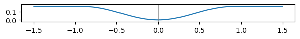

```python
plot1d(lambda u: tukey(u, 1.), (-1.5, 1.5), 201)
```

This function is convex for small values of the residual but then saturates as the residual increases, so that very distant outliers cannot incur arbitrarily large losses.

The risk is still

$$ L_T(\mathbf{z}) = \frac{1}{n} \sum_{i=1}^n \rho(\phi_i(\mathbf{z})) $$

but now the residuals are the orthogonal distances and $\rho$ is Tukey's loss function.

### Multiple Hyperplanes

The `numpy` array `points` retrieved below has shape $(n, 2)$ with $n = $ 210,000. It represents the coordinates of $n$ points on the plane.

```python
file_name = 'two_noisy_lines.pkl'
retrieve(file_name)
with open(file_name, 'rb') as file:
    points = pickle.load(file)
```

```
Using previously downloaded file two_noisy_lines.pkl
```

Here is a plot of one percent of those points:

```python
def plot_fit(dots, f=None, title=None, sampling=100):
    px, py = dots[::sampling, 0], dots[::sampling, 1]
    fig_size = figure_size(4, px, py)
    plt.figure(figsize=fig_size, tight_layout=True)
    plt.plot(px, py, '.', ms=5)
    if f is not None:
        x_range = (np.min(dots[:, 0]), np.max(dots[:, 0]))
        x = np.linspace(x_range[0], x_range[1], 2)
        y = f(x)
        plt.plot(x, y)
    plt.axis('equal')
    plot_axes()
    if title is None:
        pct = 100 / sampling
        plt.title('{:g} percent of all points'.format(pct))
    else:
        plt.title(title)
    plt.draw()
```

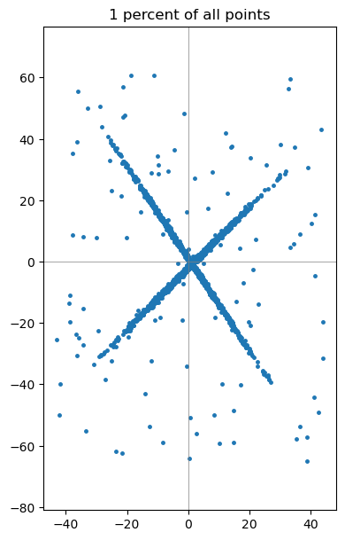

```python
plot_fit(points)
```

As you see, most points are distributed along two lines (with some noise). The two lines have equation

$$ \mathbf{n}^T\mathbf{x} = c $$

with the following parameters:

- $\mathbf{n}_1 = \frac{1}{\sqrt{2}}(1, -1)$ and $c_1 = \sqrt{2}$
- $\mathbf{n}_2 = \frac{1}{\sqrt{13}}(3, 2)$ and $c_2 = \frac{2}{\sqrt{13}}$

In addition, there are several outliers.

### Lack of Convexity

With the new formulation and the more complex data distribution, the risk is no longer necessarily a convex function of the hyperplane parameters in $\mathbf{z}$, and may have local minima, maxima, and saddle points.

Nonconvexity derives from two sources:

- Tukey's loss function is nonconvex.
- Data points concentrated along two lines yield at least two local minima, one per line.

### Stochastic Gradient Descent and Automatic Differentiation

Since the risk function $L_T(\mathbf{z})$ is the average of a very large number of losses, we use Stochastic Gradient Descent (SGD). To save you some effort, the SGD code is downloaded here, and the relevant functions are imported.

```python
retrieve('sgd.py')
from sgd import CallCounter, run_sgd, plot_fit
```

```
Using previously downloaded file sgd.py
```

It is instructive for you to browse the code. In particular, note the unusual import for `numpy`:

```
import autograd.numpy as np
```

The module `autograd.numpy` is a reimplementation of most of `numpy` to include *automatic differentiation*. This means that if you implement your functions with this module rather than the standard `numpy`, you can then let the module itself define new functions that compute the gradients of your functions. For instance, you will later provide a function that computes the Tukey losses for a set of points. This function is bound to the parameter `losses` of the function `run_sgd` in `sgd.py`. If you look at the definition of `run_sgd`, you will see that this function defines a function `risk` that computes the mean of your `losses`, and then you will see the call

```
risk_gradient = gradient(risk)
```

This is all you need to do to make a brand new function `risk_gradient` that, when called, computes the gradient of `risk`. Rather easy, no?

All of the main packages for deep learning use automatic differentiation. While this slows down the code considerably, because many things need to happen under the hood for automatic differentiation to work its magic, package users do not need to compute derivatives by hand, thereby removing one of the main sources of bugs in deep learning implementations.

### Constrained Optimization

The constraint $\|\mathbf{n}\| = 1$ in the minimization problem defined above is handled in a straightforward manner in the function `step` defined in `sgd.py`. Specifically, a regular step is first taken along the negative gradient of the risk computed on a mini-batch:

$$ \mathbf{z}_{k+1} =\mathbf{z}_k - \alpha \nabla L_B(\mathbf{z}_k) $$

where $B$ is the minibatch (a subset of $T$).

The resulting vector $\mathbf{z}_{k+1} = (c_{k+1}, \mathbf{n}_{k+1})$ is then divided by the Euclidean norm of $\mathbf{n}_{k+1}$. This division has the effect that $\mathbf{z}_{k+1}$ now satisfies the constraint. This technique is called the *projected gradient* technique. Please read the code of `step` in `sgd.py`.

### Problem 2.1

Write a function with the following decorator and header:

```
@CallCounter
def tukey_losses(z, x, tau):
```

The function computes a vector of Tukey losses for a hyperplane with paramaters `z` and on the given array `x` of points. The parameter `tau` is set to the constant $\tau$ in the definition of Tukey's loss function. More specifically,

- `z` $= (c, \mathbf{n}^T)$ is a $d+1$ dimensional parametrization of the hyperplane

$$ \mathbf{n}^T\mathbf{x} = c $$

- The array `x` has shape $(b, d)$ and each of its rows is a point in $\mathbb{R}^d$. This array contains the points in a minibatch of size $b$ out of the training set $T$. It is the responsibility of `sgd` to pass the appropriate subarray to `tukey_losses`.
- The value of $\tau$ is a positive floating-point number.
- The function `tukey_losses` returns the vector of losses $\rho(\varphi_T(\mathbf{z}))$. This vector has $b$ floating-point entries.

#### The Decorator

The decorator class `CallCounter` has been imported for you earlier from `sgd.py`. You do not need to understand Python decorators in detail to use this feature. Suffice it to say that the decoration will keep track of the cumulative number of points in $\mathbb{R}^d$ on which the function `tukey_losses` is called as SGD is run. This count is an estimate of the computational cost of SGD.

#### Your Task

Show your code for `tukey_losses` (remember to include the decorator). Then pick a batch size and a learning rate and run `run_sgd` as follows:

```
batch_size, learning_rate = ...
run_sgd(tukey_losses, points, batch_size, learning_rate)
```

The `points` array was downloaded for you earlier and the function `run_sgd` was imported earlier as well (in the paragraph on *Stochastic Gradient Descent and Automatic Differentiation*).

If you look at the definition of `run_sgd` in `sgd.py`, you will see that it has a named parameter `budget` set to `int(3e6)` (three million) by default. With this value, SGD will terminate if `tukey_losses` is called on more than that many points overall (see the discussion of the decorator `CallCounter` above for this count.) So you can consider this value as the total computational budget allowed for this computation.

**You will get full credit if you find a batch size and a learning rate for which SGD converges to either true line in `points` within the given budget.** Convergence is achieved when the Euclidean distance between the true value $\mathbf{z}^\ast$ and the value $\hat{\mathbf{z}}$ found by SGD is less than 0.1 . Parameter values for the true lines were given earlier, and SGD is supposed to converge to either of them.

The function `run_sgd` gives the following diagnostic information:

- It print out the batch size, learning rate, and total computational expense.
- It plots a fraction of all the data points and the best-fit line. The title of that plot also gives the line parameters and the error. This is the error that has to go below 0.1 .

### Problem 2.2 (Exam Style)

What does the following command do? In particular, in what way is this *not* SGD?

```
run_sgd(tukey_losses, points, points.shape[0], 0.01)
```

You do not need to run the command to answer this question.

### Problem 2.3 (Exam Style Except for the Code Run)

Run the command in the previous problem. Show the output and then explain in some detail why the code finds the solution it finds, and why this solution is different from the one you found in Problem 2.1.